# Every Tom, Dick, and Harry

Writing Functions in R

R Pruim

# Loading some packages

```r
library(babynames)
library(ggformula)
library(dplyr)
theme_set(theme_bw())
```

# What Ever Happened to Baby Jane (and Mary)?

Let’s create a plot to see how the popularity of the names Jane and Mary has changed over time.

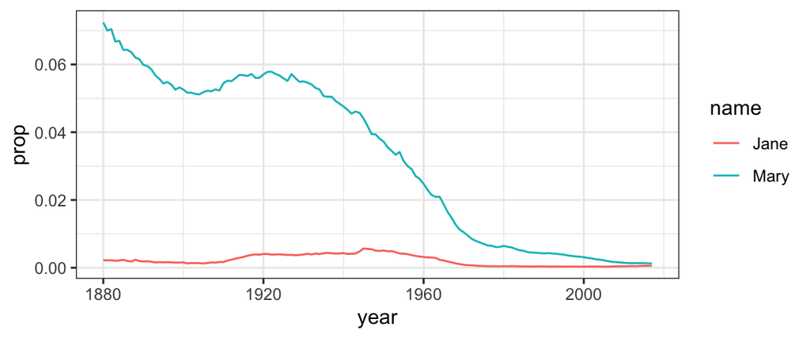

```r
babynames %>%
  filter(name %in% c("Mary", "Jane"), sex == "F") %>%
  gf_line(prop ~ year, color = ~ name)
```

# What about Tom, Dick, and Harry?

We would like to generalize our code to handle any set of names we want to compare. In R we do this by writing **functions**.

We begin with our two questions:

1. What do we want R to do?
   - This determines the name of the function (and what it does/returns)
   - `name_trend_plot()` might be a good name for the function
2. What does it need to know to do this?
   - This determines the arguemnt list (list of inputs) to the function
   - The function will need to know which names to track.
   - We should probably have an argument to restrict to just one sex.

# Creating a function in R

The general form of a fucntion definition is

```r
functionName <-
  function( arg1 = default1, arg2 = default2, ... ) {
  # do stuff here
  # result of last line is returned.
  # can also use explicit return().
}
```

# What about Tom, Dick, and Harry?

```r
name_trend_plot <-
  function(names, gender) {
    babynames %>%
      filter(name %in% names, sex == gender) %>%
      gf_line(prop ~ year, color = ~ name)
  }
```

# What about Tom, Dick, and Harry?

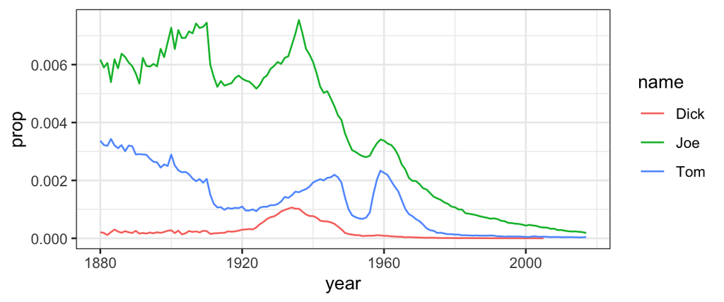

```r
name_trend_plot(c("Tom", "Dick", "Joe"), gender = "M")
```

# Adding more arguments

We can add arguments to control more features of the plot.

```r
name_trend_plot2 <-
  function(names, gender = c("M", "F"), linewidth = 1) {
    babynames %>%
      filter(name %in% names, sex %in% gender) %>%
      gf_line(prop ~ year, color = ~ name, linetype = ~ sex, size = linewidth)
  }
```

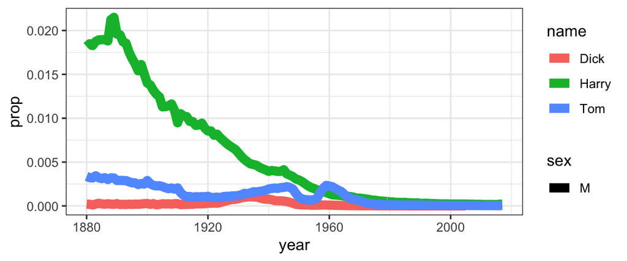

```r
name_trend_plot2( c("Tom", "Dick", "Harry"), gender = "M", linewidth = 3)
```

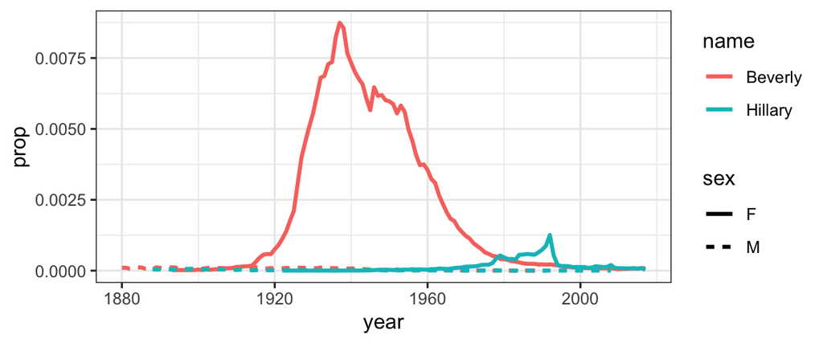

```r
name_trend_plot2( c("Hillary", "Beverly"), linewidth = 1)
```

# Dot, Dot, Dot

R functions can have a special argument called `...`. This argument holds a list of any additional arguments. It is a very handy way to pass arguments along to another function. (It has other uses, too.)

```r
name_trend_plot3 <-
  function(names, gender = c("M", "F"), ...) {
    babynames %>%
      filter(name %in% names, sex %in% gender) %>%
      gf_line(prop ~ year, color = ~ name, linetype = ~ sex, ...)
  }
```

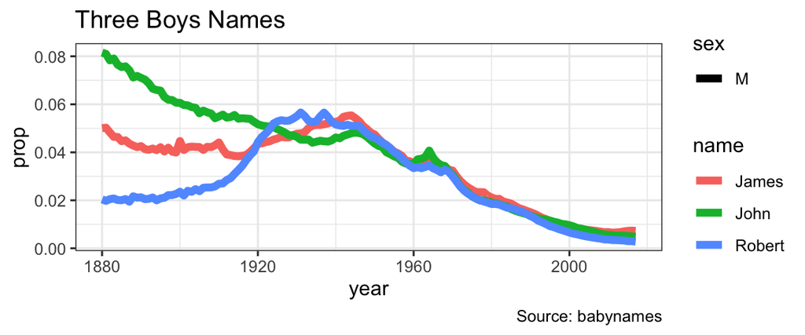

```r
name_trend_plot3(
  c("Robert", "James", "John"), gender = "M", size = 2,
  title = "Three Boys Names", caption = "Source: babynames")
```